# Heart Disease UCI

Lets load the required packages first

```r
library(readr) #to load dataset
library(tidyverse) #`tidyverse` contains packages like dplyr and ggplot which helps in exploration
library(ggthemes) #plot themes
library(corrplot) #for correlation plot
library(randomForest) #for predictive analysis
```

Now lets load the data and take a peak

```r
glimpse(heart)
```

```
Observations: 303
Variables: 14
$ age      <dbl> 63, 37, 41, 56, 57, 57, 56, 44, 52, 57, 54, 48, 49, 64, 58, 50, 58, 66, 43, 69, ...
$ sex      <dbl> 1, 1, 0, 1, 0, 1, 0, 1, 1, 1, 1, 0, 1, 1, 0, 0, 0, 0, 1, 0, 1, 1, 1, 1, 1, 0, 1,...
$ cp       <dbl> 3, 2, 1, 1, 0, 0, 1, 1, 2, 2, 0, 2, 1, 3, 3, 2, 2, 3, 0, 3, 0, 2, 0, 2, 3, 1, 2,...
$ trestbps <dbl> 145, 130, 130, 120, 120, 140, 140, 120, 172, 150, 140, 130, 130, 110, 150, 120, ...
$ chol     <dbl> 233, 250, 204, 236, 354, 192, 294, 263, 199, 168, 239, 275, 266, 211, 283, 219, ...
$ fbs      <dbl> 1, 0, 0, 0, 0, 0, 0, 0, 1, 0, 0, 0, 0, 0, 1, 0, 0, 0, 0, 0, 0, 0, 0, 1, 0, 0, 1,...
$ restecg  <dbl> 0, 1, 0, 1, 1, 1, 0, 1, 1, 1, 1, 1, 1, 0, 0, 1, 1, 1, 1, 1, 1, 1, 1, 1, 1, 1, 1,...
$ thalach  <dbl> 150, 187, 172, 178, 163, 148, 153, 173, 162, 174, 160, 139, 171, 144, 162, 158, ...
$ exang    <dbl> 0, 0, 0, 0, 1, 0, 0, 0, 0, 0, 0, 0, 0, 1, 0, 0, 0, 0, 0, 0, 0, 1, 0, 1, 1, 0, 0,...
$ oldpeak  <dbl> 2.3, 3.5, 1.4, 0.8, 0.6, 0.4, 1.3, 0.0, 0.5, 1.6, 1.2, 0.2, 0.6, 1.8, 1.0, 1.6, ...
$ slope    <dbl> 0, 0, 2, 2, 2, 1, 1, 2, 2, 2, 2, 2, 2, 1, 2, 1, 2, 0, 2, 2, 1, 2, 2, 1, 2, 2, 2,...
$ ca       <dbl> 0, 0, 0, 0, 0, 0, 0, 0, 0, 0, 0, 0, 0, 0, 0, 0, 0, 0, 0, 2, 0, 0, 0, 0, 0, 2, 0,...
$ thal     <dbl> 1, 2, 2, 2, 2, 1, 2, 3, 3, 2, 2, 2, 2, 2, 2, 2, 2, 2, 2, 2, 3, 2, 2, 2, 3, 2, 2,...
$ target   <dbl> 1, 1, 1, 1, 1, 1, 1, 1, 1, 1, 1, 1, 1, 1, 1, 1, 1, 1, 1, 1, 1, 1, 1, 1, 1, 1, 1,...
```

Here lets take a moment to understand the variables :

**[01] age** - Age in Years

**[02] sex** - 1: Male, 0: Female

**[04] trestbps** - Resting Blood Pressure (mm Hg; On Admission to the Hospital)

**[05] chol** - Cholestrol Level (mg/dl)

**[06] fbs** - Fasting Blood Sugar (> 120 mg/dl; 1: TRUE, 0: FALSE)

**[07] restecg** - Resting Electrocardiographic Measurement (0: Normal, 1: Having ST-T Wave Abnormality, 2: Showing Probable or Definite Left Ventricular Hypertrophy by Estes’ Criteria)

**[08] thalach** - Maximum Heart Rate Achieved

**[09] exang** - Exercise Induced Angina (1: Yes, 0: No)

**[10] oldpeak** - ST Depression Induced by Exercise Relative to Rest(‘ST’ denotes the positions on ECG Graph)

**[11] slope** - Slope of the Peak Exercise ST Segment (1: Upsloping, 2: Flat, 3: Downsloping)

**[12] ca** - Number of Major Vessels (0-3)

**[14] target** - Heart Disease (0: NO, 1: Yes)

Lets change the column names to make it easier to read the data

```r
colnames(heart)[1:9] <- c("Age", "Sex", "Chest_Pain", "Resting_BP", "Cholestrol", "Fasting_Blood_Sugar",
                           "Resting_ECG", "Max_Heart_Rate", "Excercise_Induced_Angina")
colnames(heart)[12:14] <- c("No._Major_Vessels", "Thalassemia", "Heart_Disease")
head(heart, n = 10)
```

| Age | Sex | Chest_Pain | Resting_BP | Cholestrol | Fasting_Blood_Sugar | Resting_ECG | Max_Heart_Rate | Excercise_Induced_Angina | oldpeak | slope | No._Major_Vessels | Thalassemia | Heart_Disease |
| --- | --- | --- | --- | --- | --- | --- | --- | --- | --- | --- | --- | --- | --- |
| 63 | 1 | 3 | 145 | 233 | 1 | 0 | 150 | 0 | 2.3 | 0 | 0 | 1 | 1 |
| 37 | 1 | 2 | 130 | 250 | 0 | 1 | 187 | 0 | 3.5 | 0 | 0 | 2 | 1 |
| 41 | 0 | 1 | 130 | 204 | 0 | 0 | 172 | 0 | 1.4 | 2 | 0 | 2 | 1 |
| 56 | 1 | 1 | 120 | 236 | 0 | 1 | 178 | 0 | 0.8 | 2 | 0 | 2 | 1 |
| 57 | 0 | 0 | 120 | 354 | 0 | 1 | 163 | 1 | 0.6 | 2 | 0 | 2 | 1 |
| 57 | 1 | 0 | 140 | 192 | 0 | 1 | 148 | 0 | 0.4 | 1 | 0 | 1 | 1 |
| 56 | 0 | 1 | 140 | 294 | 0 | 0 | 153 | 0 | 1.3 | 1 | 0 | 2 | 1 |
| 44 | 1 | 1 | 120 | 263 | 0 | 1 | 173 | 0 | 0.0 | 2 | 0 | 3 | 1 |
| 52 | 1 | 2 | 172 | 199 | 1 | 1 | 162 | 0 | 0.5 | 2 | 0 | 3 | 1 |
| 57 | 1 | 2 | 150 | 168 | 0 | 1 | 174 | 0 | 1.6 | 2 | 0 | 2 | 1 |

Next lets see the correlation between these attributes

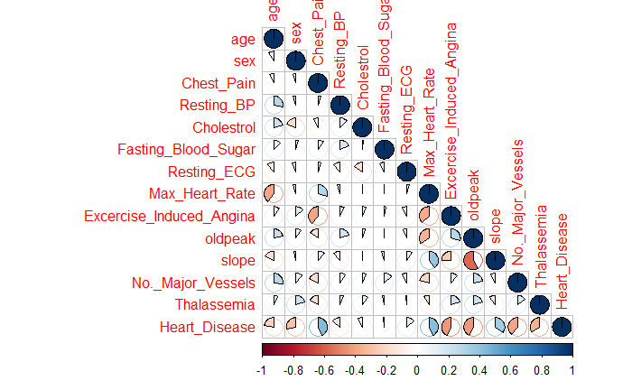

Here we find the following :

1. Chest pain and maximum heart rate has positive correlation to the presence of heart disease.
2. While, excercise induced angima, oldpeak has negative correlation.

Let’s do a bit more exploration and find out the percentage of people with heart disease in this dataset :

```r
round(table(heart$Heart_Disease)/nrow(heart), digits = 2)
```

```
   0    1
0.46 0.54
```

So about 54% has heart disease and 46% does not have a heart disease in this dataset.

Now let’s start with analysing :

first the data needs to be split

```r
sample.ind <- sample(2, nrow(heart), replace = T, prob = c(0.6,0.4))

heart.train <- heart[sample.ind==1,]
heart.test <- heart[sample.ind==2,]
```

Now let’s check the heart disease probabilities in the now split dataset :

```r
round(table(heart.train$Heart_Disease)/nrow(heart.train), digits = 2)
```

```
   0    1
0.44 0.56
```

```r
round(table(heart.test$Heart_Disease)/nrow(heart.test), digits = 2)
```

```
   0    1
0.49 0.51
```

Now let’s begin building the classification random forest :

first the formula needs to be made -

```r
attributes <- names(heart)
attributes <- attributes[!attributes %in% c("Heart_Disease")]
attributes1 <- paste(attributes, collapse = "+")
formula <- as.formula(paste("Heart_Disease", attributes1, sep = " ~ "))
```

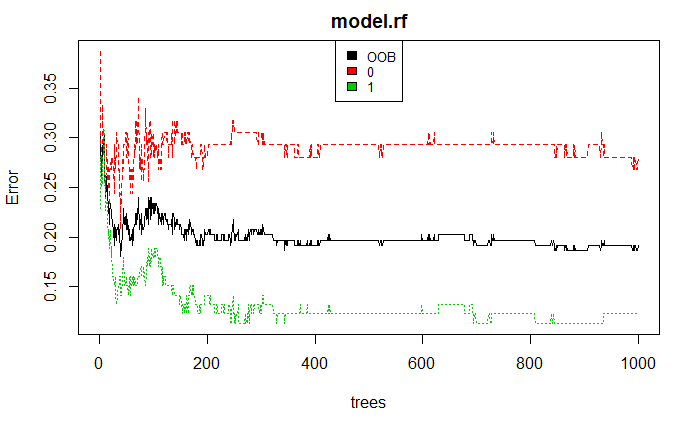

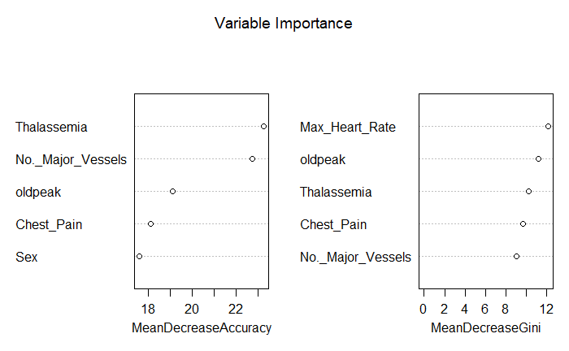

|  | MeanDecreaseGini | Variables |
| --- | --- | --- |
| Max_Heart_Rate | 12.1489132 | Max_Heart_Rate |
| oldpeak | 11.2080769 | oldpeak |
| Thalassemia | 10.1937544 | Thalassemia |
| Chest_Pain | 9.6760925 | Chest_Pain |
| No._Major_Vessels | 9.0126348 | No._Major_Vessels |
| Age | 7.8461463 | Age |
| Cholestrol | 7.5930971 | Cholestrol |
| Resting_BP | 6.8489277 | Resting_BP |
| slope | 5.7011150 | slope |
| Sex | 4.0166519 | Sex |

[output cut: 3 more lines]